# Cluster Analysis

WDI Indicators

student name

2018-07-22 00:25:14

> با توجه به داده بانک جهانی به سوالات زیر پاسخ دهید. برای استفاده از داده از سه فایل زیر استفاده نمایید. داده نام کشورها: WDICountry داده نام سری های زمانی: WDISeries داده کل: WDIData در صورتی که داده را در اختیار ندارید می توانید از بسته WDI استفاده نموده و داده های مورد نظر را استخراج نمایید.

```r
library(readr)
library(stringi)
library(stringr)
library(dplyr)
library(ggplot2)

name = c("WDICountry-Series" , "WDICountry" , "WDIData" , "WDIFootNote" , "WDISeries-Time" , "WDISeries")

files = list()

file_name = list.files("D:/University/Semester8/Data analysis/week10/WDI")

for(i in 1:6){files[[i]]= read.csv(paste("D:/University/Semester8/Data analysis/week10/WDI/" , name[i] , ".csv", sep = ""))}

WDICountry_Series = files[[1]]

WDICountry = files[[2]]

WDIData = files[[3]]

WDIFootNote = files[[4]]

WDISeries_Time = files[[5]]

WDISeries = files[[6]]
```

khate faghr = SI.POV.NAHC

۱. ده کشور فقیر دنیا را بیابید. نمودار درآمد روزانه آنها را رسم کنید. چند درصد از اعضای این کشورها زیر خط فقر هستند؟ متوسط عمر در این کشورها چقدر است؟

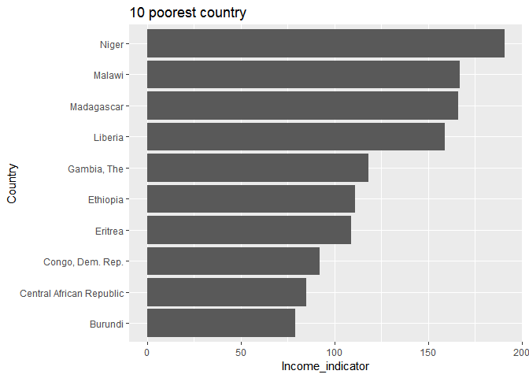

```r
income_average = WDIData %>% filter(WDIData$Indicator.Code == "NY.GNP.PCAP.CD")
con_name = income_average$ï..Country.Name
income_average = income_average %>% select(X2010 , X2011 , X2012 , X2013,X2014,X2015,X2016)

income_average = income_average %>% mutate(ave = rowMeans(income_average , na.rm = T))


a1 = sort(income_average$ave)

a = a1[1:10]

a = match(a , income_average$ave)

poor_country = con_name[a]

d = data.frame(poor_country , a)

colnames(d) = c("Country" , "Income_indicator")

ggplot(d , aes(x = Country , y = Income_indicator)) + geom_col() + coord_flip() + ggtitle("10 poorest country")
```

```r
p_coun = as.character(poor_country)
a = WDIData %>% filter(Indicator.Code == "SI.POV.NAHC")
dih_col <- which(a$ï..Country.Name %in% poor_country)
a = a[dih_col ,]

a1 = a %>% select(X1990:X2016)
a1 = rowMeans(a1 , na.rm = T)



b = WDIData %>% filter(Indicator.Code == "SP.DYN.LE00.IN")
dih_col <- which(b$ï..Country.Name %in% poor_country)
b = b[dih_col ,]
b1 = b %>% select(X1990:X2016)
b1 = rowMeans(b1 , na.rm = T)

d = data.frame(poor_country , a1 , b1)
colnames(d) = c("Country" , "Powerty gap" , "Life expectancy")

print(d)
```

[output not shown]

۲. تراژدی روآندا: بر اساس داده های امید به زندگی ابتدا نمودار سالانه نمودار جعبه ایی امید به زندگی کشورها را رسم نمایید(در یک نمودار!). سپس سری زمانی امید به زندگی روآندا را به آن اضافه کنید. چه می بینید؟ چند میلیون نفر کشته شدند؟

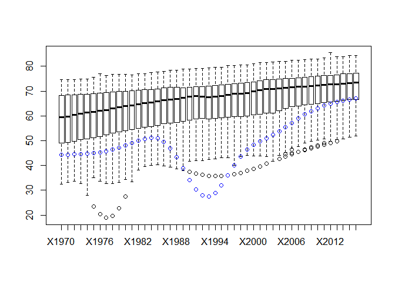

```r
WDIData %>% filter(Indicator.Code == "SP.DYN.LE00.IN") %>%
  select(Name = ï..Country.Name,X1970:X2016) -> Life_expectancy
boxplot(Life_expectancy[,-1])
points(x = 1:47,y = t(Life_expectancy[209,-1]),col = 4)
```

```r
v = (52-28)*6*1000000/52
print(paste("Number of Victims are about:",round(v)))
```

```
## [1] "Number of Victims are about: 2769231"
```

مشاهده می شود پس از آن تراژدی امید به زندگی اقت و سپس به روند قبلی خود ادامه می دهد.

۳. نمودار امید به زندگی و هزینه های بهداشتی را رسم کنید. چه نتیجه ایی می گیرید؟

در واقع با رعایت حداقل های بهداشتی می توان متوسط عمر را به شکل قابل توجهی افزایش داد.

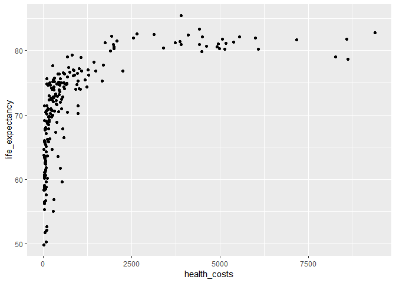

```r
life_expectancy = WDIData %>% filter(Indicator.Code == "SP.DYN.LE00.IN")
life_expectancy = life_expectancy %>% select(X2010 , X2011 , X2012 ,X2013,X2014,X2015,X2016)
life_expectancy = life_expectancy %>% mutate(ave = rowMeans(life_expectancy , na.rm = T))


health_costs = WDIData %>% filter(Indicator.Code == "SH.XPD.CHEX.PC.CD")
health_costs = health_costs %>% select(X2010 , X2011 , X2012 , X2013,X2014,X2015,X2016)
health_costs = health_costs %>% mutate(ave = rowMeans(health_costs , na.rm = T))


d = data.frame(life_expectancy$ave , health_costs$ave)
colnames(d) = c("life_expectancy" , "health_costs") #every contry has just one of these codes so they will be automaticlly merged

ggplot(d , aes(x = health_costs , y = life_expectancy)) + geom_point()
```

۴. آیا قدرت خرید خانواده های ایرانی در ۵۰ سال اخیر افزایش یافته است؟ برای این کار از داده های اقتصادی خانوار استفاده کنید.

```r
household_consumption = WDIData %>% filter(Indicator.Code == "NE.CON.PETC.CD")

household_consumption = household_consumption %>% filter(household_consumption$ï..Country.Name == "Iran, Islamic Rep.")

year = c(1967:2016)
consumption_power = as.numeric(household_consumption %>% select(X1967:X2016))

year = year[!is.na(consumption_power)]

consumption_power = consumption_power[!is.na(consumption_power)]
cor(year,consumption_power,method = "spearman" )
```

```
## [1] 0.8471559
```

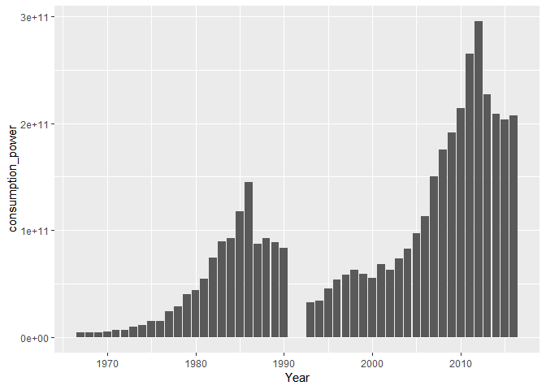

```r
d = data.frame(year , consumption_power)
colnames(d) = c("Year" , "consumption_power")

ggplot(d , aes(x = Year , y = consumption_power)) + geom_col()
```

۵. رشد اقتصادی ایران را با کشورهای دیگر در طول ۲۰ سال گذشته بر حسب بیست شاخص های اقتصادی مهم مانند تولید ناخالص ملی، تورم و … ارزیابی کنید! (برای هر شاخص از تصویرسازی استفاده کنید.)

```r
ind = c("SL.IND.EMPL.MA.ZS","FR.INR.DPST","SL.UEM.TOTL.NE.ZS","EG.USE.ELEC.KH.PC","SL.TLF.TOTL.IN","EG.ELC.PETR.ZS","SP.DYN.LE00.IN","SP.POP.TOTL","SI.POV.GAPS","SL.FAM.WORK.MA.ZS","SL.FAM.WORK.ZS","NY.ADJ.NNTY.CD","SL.GDP.PCAP.EM.KD","SL.IND.EMPL.FE.ZS","SL.IND.EMPL.ZS","SH.XPD.CHEX.PC.CD","FP.CPI.TOTL.ZG","NY.GDP.MKTP.KD.ZG","SL.SRV.EMPL.MA.ZS","SL.SRV.EMPL.ZS")

WDIData$Country.Code %>% unique() ->countryCodes
j = 1
countryList = list()
for (i in countryCodes) {
  WDIData %>% filter((Indicator.Code %in% ind)&(Country.Code == i)) %>%
   select(Indicator.Code,X2016,X2015,X2014,X2013,X2012,X2011,X2010,X2009,X2008,
          X2007,X2006,X2005,X2004,X2003,X2002,X2001,X2000,X1999,X1998,X1997) -> countryList[[j]]
  j = j+1
}

c = NULL
f = NULL
for (i in 1:264) {
  c = countryList[[i]][1:20,-1] %>% colMeans(na.rm = T)
  if (i == 1) {
    f <- data.frame(c)
  }
  else{
    f <- data.frame(f,c)
  }
}
colnames(f) = countryCodes
ff = data.frame(rownames(f),f)
colnames(ff) = c("Year",colnames(f))
kk = ff[,2:264]
ff = ff %>% mutate(ave = rowMeans(kk , na.rm = T))




p1 = ggplot(data = ff) + geom_point(aes(x = Year , y = IRN) , color = 'red') + geom_point(aes(x = Year , y = ave) , color = 'blue') + xlab("Year") + ylab("IRN vs AVERAGE")


print(p1)
```

[output not shown]

۶. در قسمت قبل با استفاده از روش خوشه بندی k-means داده ها را به سه دسته تقسیم کنید. ایران در کدام دسته می گنجد؟ (پیش از خوشه بندی طبیعتا داده را باید پاکسازی و استاندارد سازی نمایید.)

```r
cont = NULL
data = NULL
for (i in 1:264) {
  cont = countryList[[i]][,2:21] %>% rowMeans(na.rm = T)
  if (i == 1) {
    data <- data.frame(cont)
  }
  else{
    data <- data.frame(data,cont)
  }
}
colnames(data) = countryCodes


data[is.na(data)] <- 0
x = kmeans(t(data),centers = 3)
print(x$cluster)
```

```
## ARB CSS CEB EAR EAS EAP TEA EMU ECS ECA TEC EUU FCS HPC HIC IBD IBT IDB
##   1   1   1   1   3   1   1   3   3   1   1   3   1   1   2   3   3   1
## IDX IDA LTE LCN LAC TLA LDC LMY LIC LMC MEA MNA TMN MIC NAC INX OED OSS
##   1   1   3   1   1   1   1   3   1   1   1   1   1   3   3   1   2   1
## PSS PST PRE SST SAS TSA SSF SSA TSS UMC WLD AFG ALB DZA ASM AND AGO ATG
##   1   2   1   1   1   1   1   1   1   3   2   1   1   1   1   1   1   1
## ARG ARM ABW AUS AUT AZE BHS BHR BGD BRB BLR BEL BLZ BEN BMU BTN BOL BIH
##   1   1   1   1   1   1   1   1   1   1   1   1   1   1   1   1   1   1
## BWA BRA VGB BRN BGR BFA BDI CPV KHM CMR CAN CYM CAF TCD CHI CHL CHN COL
##   1   1   1   1   1   1   1   1   1   1   1   1   1   1   1   1   1   1
## COM COD COG CRI CIV HRV CUB CUW CYP CZE DNK DJI DMA DOM ECU EGY SLV GNQ
##   1   1   1   1   1   1   1   1   1   1   1   1   1   1   1   1   1   1
## ERI EST ETH FRO FJI FIN FRA PYF GAB GMB GEO DEU GHA GIB GRC GRL GRD GUM
##   1   1   1   1   1   1   1   1   1   1   1   1   1   1   1   1   1   1
## GTM GIN GNB GUY HTI HND HKG HUN ISL IND IDN IRN IRQ IRL IMN ISR ITA JAM
##   1   1   1   1   1   1   1   1   1   1   1   1   1   1   1   1   1   1
## JPN JOR KAZ KEN KIR PRK KOR XKX KWT KGZ LAO LVA LBN LSO LBR LBY LIE LTU
##   1   1   1   1   1   1   1   1   1   1   1   1   1   1   1   1   1   1
## LUX MAC MKD MDG MWI MYS MDV MLI MLT MHL MRT MUS MEX FSM MDA MCO MNG MNE
##   1   1   1   1   1   1   1   1   1   1   1   1   1   1   1   1   1   1
## MAR MOZ MMR NAM NRU NPL NLD NCL NZL NIC NER NGA MNP NOR OMN PAK PLW PAN
##   1   1   1   1   1   1   1   1   1   1   1   1   1   1   1   1   1   1
## PNG PRY PER PHL POL PRT PRI QAT ROU RUS RWA WSM SMR STP SAU SEN SRB SYC
##   1   1   1   1   1   1   1   1   1   1   1   1   1   1   1   1   1   1
## SLE SGP SXM SVK SVN SLB SOM ZAF SSD ESP LKA KNA LCA MAF VCT SDN SUR SWZ
##   1   1   1   1   1   1   1   1   1   1   1   1   1   1   1   1   1   1
## SWE CHE SYR TJK TZA THA TLS TGO TON TTO TUN TUR TKM TCA TUV UGA UKR ARE
##   1   1   1   1   1   1   1   1   1   1   1   1   1   1   1   1   1   1
## GBR USA URY UZB VUT VEN VNM VIR PSE YEM ZMB ZWE
##   1   3   1   1   1   1   1   1   1   1   1   1
```

۷. به وسیله تحلیل مولفه اصلی بعد داده رو به دو کاهش دهید سپس خوشه های به دست آمده در قسمت قبل را بر روی آن نمایش دهید. آیا عملکرد روش خوشه بندی شما مطلوب بوده است؟

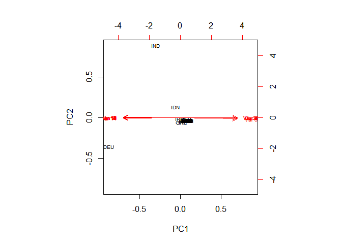

```r
pca = prcomp(t(data),  scale.=T)
eigen_val = round(pca$sdev^2/sum(pca$sdev^2)*100, 2)
eigen_val = data.frame(c(1:20),eigen_val)
names(eigen_val) = c('PCs','Var')
chosen.components = c(1,2)
feature.vector = pca$rotation[,chosen.components]
compact.data = as.matrix(t(feature.vector)) %*% as.matrix(data)
approx.d = t(feature.vector %*% compact.data)
biplot(prcomp(approx.d[120:140,],scale. = T),cex=0.6)
```

با توجه به زاویه و اندازه های نمودار biplot و کلاستربندی انجام شده تا حدی تطابق و گروه ها دیده می شود(با تغییر مشخصات biplot با دقت بیشتری می توان پی برد.)

۸. با استفاده از داده روشی برای پیش بینی رشد اقتصادی ایران در سال آینده ارائه دهید.

```r
year = c(1997:2016)

fit = lm(ff$IRN~year)

ff$IRN[20]-(coef(fit)[1] + 2016*coef(fit)[2])-> ll

print(paste("Economic growth in 2017 will be:",coef(fit)[1] + 2017*coef(fit)[2] + ll))
```

```
## [1] "Economic growth in 2017 will be: 4255007290.0368"
```

۹. سوالهای ۵ تا ۷ را ابتدا برای ۲۰ شاخص سلامت سپس بر حسب ۲۰ شاخص آموزشی تکرار کنید.

```r
health_ind = c("NY.GDP.MKTP.KD.ZG","FP.CPI.TOTL.ZG","FR.INR.DPST","EG.ELC.PETR.ZS","SL.UEM.TOTL.NE.ZS","EG.USE.ELEC.KH.PC","SL.TLF.TOTL.IN","SP.DYN.LE00.IN","SP.POP.TOTL","NY.ADJ.NNTY.CD","SI.POV.GAPS","SL.FAM.WORK.MA.ZS","SL.FAM.WORK.ZS","SL.GDP.PCAP.EM.KD","SL.IND.EMPL.FE.ZS","SL.IND.EMPL.MA.ZS","SL.IND.EMPL.ZS","SH.XPD.CHEX.PC.CD","SL.SRV.EMPL.MA.ZS","SL.SRV.EMPL.ZS")



WDIData$Country.Code %>% unique() ->countryCodes   #IRN is 138
j = 1
countryList = list()
for (i in countryCodes) {
  WDIData %>% filter((Indicator.Code %in% health_ind)&(Country.Code == i)) %>%
   select(Indicator.Code,X2016,X2015,X2014,X2013,X2012,X2011,X2010,X2009,X2008,
          X2007,X2006,X2005,X2004,X2003,X2002,X2001,X2000,X1999,X1998,X1997) -> countryList[[j]]
  j = j+1
}

c = NULL
f = NULL
for (i in 1:264) {
  c = countryList[[i]][1:20,-1] %>% colMeans(na.rm = T)
  if (i == 1) {
    f <- data.frame(c)
  }
  else{
    f <- data.frame(f,c)
  }
}
colnames(f) = countryCodes
ff = data.frame(rownames(f),f)
colnames(ff) = c("Year",colnames(f))
kk = ff[,2:264]
ff = ff %>% mutate(ave = rowMeans(kk , na.rm = T))




p1 = ggplot(data = ff) + geom_point(aes(x = Year , y = IRN) , color = 'red') + geom_point(aes(x = Year , y = ave) , color = 'blue') + xlab("Year") + ylab("IRN vs AVERAGE")


print(p1)
```

[output not shown]

```r
cont = NULL
data = NULL
for (i in 1:264) {
  cont = countryList[[i]][,2:21] %>% rowMeans(na.rm = T)
  if (i == 1) {
    data <- data.frame(cont)
  }
  else{
    data <- data.frame(data,cont)
  }
}
colnames(data) = countryCodes


data[is.na(data)] <- 0
x = kmeans(t(data),centers = 3)
print(x$cluster)
```

```
## ARB CSS CEB EAR EAS EAP TEA EMU ECS ECA TEC EUU FCS HPC HIC IBD IBT IDB
##   3   3   3   3   2   3   3   2   2   3   3   2   3   3   1   2   2   3
## IDX IDA LTE LCN LAC TLA LDC LMY LIC LMC MEA MNA TMN MIC NAC INX OED OSS
##   3   3   2   3   3   3   3   2   3   3   3   3   3   2   2   3   1   3
## PSS PST PRE SST SAS TSA SSF SSA TSS UMC WLD AFG ALB DZA ASM AND AGO ATG
##   3   1   3   3   3   3   3   3   3   2   1   3   3   3   3   3   3   3
## ARG ARM ABW AUS AUT AZE BHS BHR BGD BRB BLR BEL BLZ BEN BMU BTN BOL BIH
##   3   3   3   3   3   3   3   3   3   3   3   3   3   3   3   3   3   3
## BWA BRA VGB BRN BGR BFA BDI CPV KHM CMR CAN CYM CAF TCD CHI CHL CHN COL
##   3   3   3   3   3   3   3   3   3   3   3   3   3   3   3   3   3   3
## COM COD COG CRI CIV HRV CUB CUW CYP CZE DNK DJI DMA DOM ECU EGY SLV GNQ
##   3   3   3   3   3   3   3   3   3   3   3   3   3   3   3   3   3   3
## ERI EST ETH FRO FJI FIN FRA PYF GAB GMB GEO DEU GHA GIB GRC GRL GRD GUM
##   3   3   3   3   3   3   3   3   3   3   3   3   3   3   3   3   3   3
## GTM GIN GNB GUY HTI HND HKG HUN ISL IND IDN IRN IRQ IRL IMN ISR ITA JAM
##   3   3   3   3   3   3   3   3   3   3   3   3   3   3   3   3   3   3
## JPN JOR KAZ KEN KIR PRK KOR XKX KWT KGZ LAO LVA LBN LSO LBR LBY LIE LTU
##   3   3   3   3   3   3   3   3   3   3   3   3   3   3   3   3   3   3
## LUX MAC MKD MDG MWI MYS MDV MLI MLT MHL MRT MUS MEX FSM MDA MCO MNG MNE
##   3   3   3   3   3   3   3   3   3   3   3   3   3   3   3   3   3   3
## MAR MOZ MMR NAM NRU NPL NLD NCL NZL NIC NER NGA MNP NOR OMN PAK PLW PAN
##   3   3   3   3   3   3   3   3   3   3   3   3   3   3   3   3   3   3
## PNG PRY PER PHL POL PRT PRI QAT ROU RUS RWA WSM SMR STP SAU SEN SRB SYC
##   3   3   3   3   3   3   3   3   3   3   3   3   3   3   3   3   3   3
## SLE SGP SXM SVK SVN SLB SOM ZAF SSD ESP LKA KNA LCA MAF VCT SDN SUR SWZ
##   3   3   3   3   3   3   3   3   3   3   3   3   3   3   3   3   3   3
## SWE CHE SYR TJK TZA THA TLS TGO TON TTO TUN TUR TKM TCA TUV UGA UKR ARE
##   3   3   3   3   3   3   3   3   3   3   3   3   3   3   3   3   3   3
## GBR USA URY UZB VUT VEN VNM VIR PSE YEM ZMB ZWE
##   3   2   3   3   3   3   3   3   3   3   3   3
```

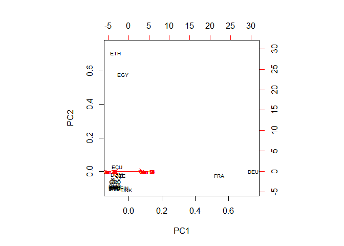

```r
pca = prcomp(t(data),  scale.=T)
eigen_val = round(pca$sdev^2/sum(pca$sdev^2)*100, 2)
eigen_val = data.frame(c(1:20),eigen_val)
names(eigen_val) = c('PCs','Var')
chosen.components = c(1,2)
feature.vector = pca$rotation[,chosen.components]
compact.data = as.matrix(t(feature.vector)) %*% as.matrix(data)
approx.d = t(feature.vector %*% compact.data)
biplot(prcomp(approx.d[100:120,],scale. = T),cex=0.6)
```

```r
education_ind = c("NY.GDP.MKTP.KD.ZG","FP.CPI.TOTL.ZG","FR.INR.DPST","EG.ELC.PETR.ZS","SL.UEM.TOTL.NE.ZS","EG.USE.ELEC.KH.PC","SL.TLF.TOTL.IN","SP.DYN.LE00.IN","SP.POP.TOTL","NY.ADJ.NNTY.CD","SI.POV.GAPS","SL.FAM.WORK.MA.ZS","SL.FAM.WORK.ZS","SL.GDP.PCAP.EM.KD","SL.IND.EMPL.FE.ZS","SL.IND.EMPL.MA.ZS","SL.IND.EMPL.ZS","SH.XPD.CHEX.PC.CD","SL.SRV.EMPL.MA.ZS","SL.SRV.EMPL.ZS")



WDIData$Country.Code %>% unique() ->countryCodes   #IRN is 138
j = 1
countryList = list()
for (i in countryCodes) {
  WDIData %>% filter((Indicator.Code %in% education_ind)&(Country.Code == i)) %>%
   select(Indicator.Code,X2016,X2015,X2014,X2013,X2012,X2011,X2010,X2009,X2008,
          X2007,X2006,X2005,X2004,X2003,X2002,X2001,X2000,X1999,X1998,X1997) -> countryList[[j]]
  j = j+1
}

c = NULL
f = NULL
for (i in 1:264) {
  c = countryList[[i]][1:20,-1] %>% colMeans(na.rm = T)
  if (i == 1) {
    f <- data.frame(c)
  }
  else{
    f <- data.frame(f,c)
  }
}
colnames(f) = countryCodes
ff = data.frame(rownames(f),f)
colnames(ff) = c("Year",colnames(f))
kk = ff[,2:264]
ff = ff %>% mutate(ave = rowMeans(kk , na.rm = T))




p1 = ggplot(data = ff) + geom_point(aes(x = Year , y = IRN) , color = 'red') + geom_point(aes(x = Year , y = ave) , color = 'blue') + xlab("Year") + ylab("IRN vs AVERAGE")


print(p1)
```

[output not shown]

```r
cont = NULL
data = NULL
for (i in 1:264) {
  cont = countryList[[i]][,2:21] %>% rowMeans(na.rm = T)
  if (i == 1) {
    data <- data.frame(cont)
  }
  else{
    data <- data.frame(data,cont)
  }
}
colnames(data) = countryCodes


data[is.na(data)] <- 0
x = kmeans(t(data),centers = 3)
print(x$cluster)
```

```
## ARB CSS CEB EAR EAS EAP TEA EMU ECS ECA TEC EUU FCS HPC HIC IBD IBT IDB
##   1   1   1   1   3   1   1   3   3   1   1   3   1   1   2   3   3   1
## IDX IDA LTE LCN LAC TLA LDC LMY LIC LMC MEA MNA TMN MIC NAC INX OED OSS
##   1   1   3   1   1   1   1   3   1   1   1   1   1   3   3   1   2   1
## PSS PST PRE SST SAS TSA SSF SSA TSS UMC WLD AFG ALB DZA ASM AND AGO ATG
##   1   2   1   1   1   1   1   1   1   3   2   1   1   1   1   1   1   1
## ARG ARM ABW AUS AUT AZE BHS BHR BGD BRB BLR BEL BLZ BEN BMU BTN BOL BIH
##   1   1   1   1   1   1   1   1   1   1   1   1   1   1   1   1   1   1
## BWA BRA VGB BRN BGR BFA BDI CPV KHM CMR CAN CYM CAF TCD CHI CHL CHN COL
##   1   1   1   1   1   1   1   1   1   1   1   1   1   1   1   1   1   1
## COM COD COG CRI CIV HRV CUB CUW CYP CZE DNK DJI DMA DOM ECU EGY SLV GNQ
##   1   1   1   1   1   1   1   1   1   1   1   1   1   1   1   1   1   1
## ERI EST ETH FRO FJI FIN FRA PYF GAB GMB GEO DEU GHA GIB GRC GRL GRD GUM
##   1   1   1   1   1   1   1   1   1   1   1   1   1   1   1   1   1   1
## GTM GIN GNB GUY HTI HND HKG HUN ISL IND IDN IRN IRQ IRL IMN ISR ITA JAM
##   1   1   1   1   1   1   1   1   1   1   1   1   1   1   1   1   1   1
## JPN JOR KAZ KEN KIR PRK KOR XKX KWT KGZ LAO LVA LBN LSO LBR LBY LIE LTU
##   1   1   1   1   1   1   1   1   1   1   1   1   1   1   1   1   1   1
## LUX MAC MKD MDG MWI MYS MDV MLI MLT MHL MRT MUS MEX FSM MDA MCO MNG MNE
##   1   1   1   1   1   1   1   1   1   1   1   1   1   1   1   1   1   1
## MAR MOZ MMR NAM NRU NPL NLD NCL NZL NIC NER NGA MNP NOR OMN PAK PLW PAN
##   1   1   1   1   1   1   1   1   1   1   1   1   1   1   1   1   1   1
## PNG PRY PER PHL POL PRT PRI QAT ROU RUS RWA WSM SMR STP SAU SEN SRB SYC
##   1   1   1   1   1   1   1   1   1   1   1   1   1   1   1   1   1   1
## SLE SGP SXM SVK SVN SLB SOM ZAF SSD ESP LKA KNA LCA MAF VCT SDN SUR SWZ
##   1   1   1   1   1   1   1   1   1   1   1   1   1   1   1   1   1   1
## SWE CHE SYR TJK TZA THA TLS TGO TON TTO TUN TUR TKM TCA TUV UGA UKR ARE
##   1   1   1   1   1   1   1   1   1   1   1   1   1   1   1   1   1   1
## GBR USA URY UZB VUT VEN VNM VIR PSE YEM ZMB ZWE
##   1   3   1   1   1   1   1   1   1   1   1   1
```

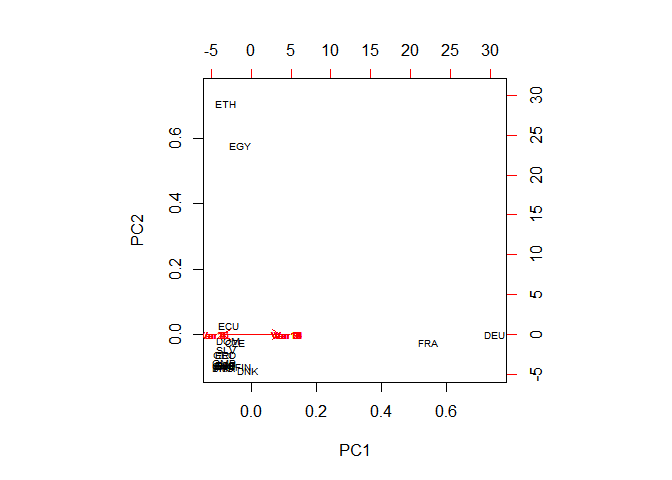

```r
pca = prcomp(t(data),  scale.=T)
eigen_val = round(pca$sdev^2/sum(pca$sdev^2)*100, 2)
eigen_val = data.frame(c(1:20),eigen_val)
names(eigen_val) = c('PCs','Var')
chosen.components = c(1,2)
feature.vector = pca$rotation[,chosen.components]
compact.data = as.matrix(t(feature.vector)) %*% as.matrix(data)
approx.d = t(feature.vector %*% compact.data)
biplot(prcomp(approx.d[100:120,],scale. = T),cex=0.6)
```

۱۰. کشورهای دنیا را بر حسب ۶۰ شاخص اقتصادی، سلامت و آموزش با روش سلسله مراتبی خوشه بندی کرده و دندروگرام آن را رسم نمایید. اگر داده ها بر سه دسته تقسیم شوند ایران در کدام دسته می گنجد؟

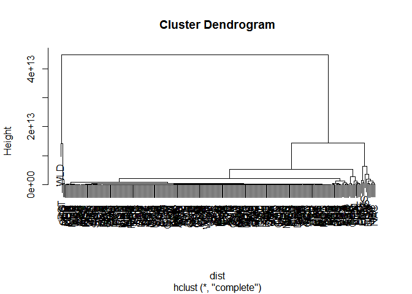

```r
dist = stats::dist(t(data),method = "euclidean")
clus = hclust(dist,method = "complete")
plot(clus)
```

۱۱. سه یافته جالب از داده ها استخراج کنید.

1.در سال های مقارن با جنگ ایران و یا تحریم شدن ایران مشاهده می شود رشد اقتصادی افت می کند مطابق آنچه انتظار می رود.

2.سلامتی بدون هیچ تدبیری به شدت در یک جامعه افت می کند و دولت ها حتما باید حداقل های بهداشتی جامعه را فراهم کنند تا میزان شاخص های سلامتی از حد معینی عبور کند.

تعداد کمی از کشور ها در اکثر فاکتور های رفاهی از باقی کشور ها به شدت جلو هستند و این که می گویند 95 درصد ثروت جهان در دست 5 درصد جمعیت آن است بی معنی نیست.